# rmonad: pipelines you can compute on

The [*rmonad*](https://CRAN.R-project.org/package=rmonad) package presents a monadic pipeline toolset for chaining functions into stateful, branching pipelines. As functions in the pipeline are run, their results are merged into a graph of all past operations. The resulting structure allows downstream computation on node documentation, intermediate data, performance stats, and any raised messages, warnings or errors, as well as the final results. [*rmonad*](https://CRAN.R-project.org/package=rmonad) is a novel approach to designing reproducible, well-documented, and maintainable workflows in R.

Zebulun Arendsee (Iowa State University) , Jennifer Chang (Iowa State University) , Eve Wurtele (Iowa State University)  
2022-06-21

## 1 Background

Pipeline programming is common practice in the R community, with [*magrittr*](https://CRAN.R-project.org/package=magrittr), [*pipeR*](https://CRAN.R-project.org/package=pipeR), and [*wrapr*](https://CRAN.R-project.org/package=wrapr) packages offering infix pipe operators (Bache and Wickham 2014; Ren 2016; Mount and Zumel 2018). The value on the left of the pipe operator is passed as the first argument to the right-hand function. This style of programming simplifies code by removing the need to name intermediate values or write deeply nested function calls. For example, using the [*magrittr*](https://CRAN.R-project.org/package=magrittr) pipe operator, `%>%`, the expression `x %>% f %>% g` is equivalent to `g(f(x))`. These pipelines are equivalent to applied function compositions and termed function *composition* pipelines.

A monadic (Wadler 1990) pipeline extends composition pipelines by allowing *context* to be threaded through the pipeline. Each function call in the pipeline produces both a new value (assuming successful evaluation) and a computational context surrounding that new value. This new value and context is then merged with the context of the prior node in the pipeline, allowing past context to be stored. In this way, monadic pipelines can be automatically self-describing by returning both the result and a description of the process that created it.

In this paper, we present [*rmonad*](https://CRAN.R-project.org/package=rmonad), the first explicitly monadic pipeline program developed for the R language. [*rmonad*](https://CRAN.R-project.org/package=rmonad) captures the history of a pipeline as a graph of all past operations. Each node in the graph represents either an input or a function. These nodes store the source code, documentation, any raised messages/warnings/errors, benchmarking info, and arbitrary additional metadata. [*rmonad*](https://CRAN.R-project.org/package=rmonad) also generalizes the standard linear pipeline to a directed graph with support for branching and looping pipelines.

[*rmonad*](https://CRAN.R-project.org/package=rmonad) is one of many graph-based workflow tools available to R programmers. The [*drake*](https://CRAN.R-project.org/package=drake) package (Landau 2017) allows specification of R workflows using Make-family semantics (Stallman et al. 2002). The R packages [*tidycwl*](https://CRAN.R-project.org/package=tidycwl) (Koc et al. 2020) and [*sevenbridges*](https://CRAN.R-project.org/package=sevenbridges) (Xiao and Yin 2020) wrap the Common Workflow Language which allows specification of DAG-based workflows that can be easily run on high-performance platforms. Many build systems allow execution of R code snippets, such as Snakemake (Köster and Rahmann 2012), Nextflow (Di Tommaso et al. 2017) and Cuneiform (Brandt et al. 2017). Like these programs, [*rmonad*](https://CRAN.R-project.org/package=rmonad) specifies a graph of dependent operations and can handle large, complex projects. However, [*rmonad*](https://CRAN.R-project.org/package=rmonad) offers a lighter solution, with no dependencies outside R. In the simplest case, [*rmonad*](https://CRAN.R-project.org/package=rmonad) has no more syntactic complexity than a composition pipeline like [*magrittr*](https://CRAN.R-project.org/package=magrittr).

Since [*rmonad*](https://CRAN.R-project.org/package=rmonad) can annotate and summarize intermediate data, it can serve as a provenance tracking tool. Provenance tracking of data generated through a pipeline is critical for research reproducibility (Gentleman and Lang 2007). For example, the provenance manager VisTrails builds directed acyclic graphs (DAG) of workflows and stores intermediate data objects as external XML files in an external database (Silva et al. 2010). It also provides a visualization of the workflow (or provenance trail) as it is being run. By visualizing the workflow in a DAG-like structure, the user can perform exploratory analysis and retooling on the fly. The R provenance tracking packages [*archivist*](https://CRAN.R-project.org/package=archivist) (Biecek and Kosinski 2017), [*trackr*](https://CRAN.R-project.org/package=trackr) (Becker et al. 2019), and [*adapr*](https://CRAN.R-project.org/package=adapr) (Gelfond et al. 2018) store manual annotations (metadata) of data objects as hooks to an external binary or JSON database.

In the following sections, we introduce the [*rmonad*](https://CRAN.R-project.org/package=rmonad) monadic pipeline operator, show how [*rmonad*](https://CRAN.R-project.org/package=rmonad) generalizes linear pipelines to support branching and nesting, describe how [*rmonad*](https://CRAN.R-project.org/package=rmonad) evaluation allows pipeline debugging and annotation, tie these ideas together with a case study, and provide an overview of the application of [*rmonad*](https://CRAN.R-project.org/package=rmonad) to a large-scale project.

## 2 The monadic pipe operator

A pipeline consists of a series of expressions that are evaluated using upstream data as input. The context that is passed through an [*rmonad*](https://CRAN.R-project.org/package=rmonad) pipeline is stored as an “Rmonad” S4 object. This object consists of a directed graph of the relationships between nodes in the pipelines, a list containing the information about each node (including the output if it is cached), and a unique identifier for the head node—the node whose output will be passed to the next operation in the pipeline. Each expression in the pipeline is evaluated by the special [*rmonad*](https://CRAN.R-project.org/package=rmonad) function, `evalwrap`, that takes an R expression and returns an “Rmonad” object. After each new expression in a pipeline is evaluated, the past “Rmonad” object is merged with the new one (see Algorithm 1).

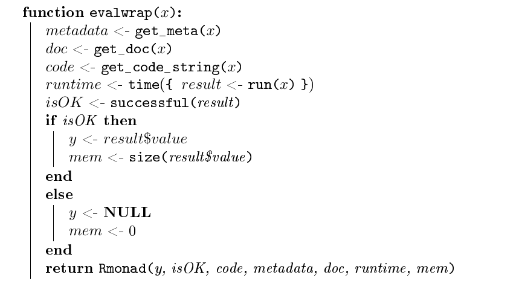

Algorithm 1: Pseudocode for the [*rmonad*](https://CRAN.R-project.org/package=rmonad) eval function, `evalwrap`. `get_meta` and `get_doc` are functions that parse the input expression to extract the documentation string and metadata list. `get_code_string` gets the R code of the function as a string. These three functions rely on the metaprogramming features of R, which allow functions to operate on the code of their inputs. The `run` function is like the standard `eval` R function except that it captures error/warning/message output and returns these together with the output value as a list. `$` is used to access a value in a list. `successful` returns TRUE if the evaluation raised no error. `size` returns the memory footprint of an R object. `Rmonad` is a constructor for an “Rmonad” object. In summary, `evalwrap` evaluates a function call, captures any raised messages, records information about the function and its output, and returns a new “Rmonad” object.

The [*rmonad*](https://CRAN.R-project.org/package=rmonad) function `evalwrap` evaluates an R expression and returns an “Rmonad” object. The type signature of `evalwrap` is:

$$\text{evalwrap} :: R \rightarrow M\ a$$

The `evalwrap` function takes the R expression, $R$, and returns $M\ a$, which is the “Rmonad” object $M$ wrapping the value returned from the evaluation of $R$. On success, the returned value has type $a$. Thus, whereas a composition pipeline would consist of chained functions of type $a \rightarrow b$, $b \rightarrow c$, $c \rightarrow d$, etc, an [*rmonad*](https://CRAN.R-project.org/package=rmonad) pipeline consists of $a \rightarrow M\ b$, $b \rightarrow M\ c$, $c \rightarrow M\ d$.

Each evaluation step in an [*rmonad*](https://CRAN.R-project.org/package=rmonad) pipeline creates a contextualized object. However, including the context in the output causes a type conflict. For example, suppose there are functions $f$ and $g$ with types ($a \rightarrow M\ b$) and ($b \rightarrow M\ c$), respectively. Function $f$ produces an output of type $M\ b$, but function $g$ requires an input of type $b$. This conflict is resolved through the special evaluation performed within the monadic pipe operator.

The monadic pipe operator, or the bind operator, has the type signature (Wadler 1990):

$$bind\ ::
\underbrace{m\ b}_{\text{output of $f$}} \rightarrow
\underbrace{(b \rightarrow m\ c)}_{\text{the function $g$}} \rightarrow
\underbrace{m\ c}_{\text{output of $g$}}$$

where $m$ is a generic monad. The function `bind` takes an input of type $m\ b$ and the function $g$ of type ($b \rightarrow m\ c$). It returns the output of $g$ which has type $m\ c$. Many functions of the general type $a \rightarrow m\ b$ can be chained together using this `bind` function. For example, the call `bind(bind(f(x), g),h)` would chain the contextualized results of $f$ through $g$ and then $h$. The implementation of the bind function defines how context from $m\ b$ is passed through the monadic chain to $m\ c$.

The simplest possible implementation of the `bind` function passes no state and is identical to applied functional composition (e.g., as done in [*magrittr*](https://CRAN.R-project.org/package=magrittr)):

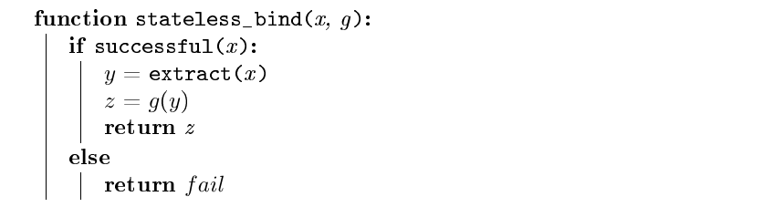

Algorithm 2: The bind function for a *composition* pipeline where no context is passed. `successful` returns TRUE if the previous operation succeeded. `extract` returns the stored value from the monadic wrapper. $g$ operates on the $y$ and returns the wrapped value $z$.

The monadic pipeline operator of [*rmonad*](https://CRAN.R-project.org/package=rmonad), `%>>%`, has the type signature:

$$\underbrace{M\ a}_{lhs} \rightarrow \underbrace{(a \rightarrow \ b)}_{rhs} \rightarrow \underbrace{M\ b}_{output}$$

`%>>%` is a binary operator where the left hand side (`lhs`) is an “Rmonad” object ($M$) wrapping a value of type $a$. The right hand side (`rhs`) is a normal R function that takes an input of type $a$ and, if successful, returns a value of type $b$. If `lhs` stores a failing state (i.e., a prior node in the pipeline raised an error), then the `rhs` function is not evaluated and the failed state is propagated. Otherwise, the value is extracted from `lhs` and `evalwrap` then evaluates the `rhs` function with the `lhs` value as its first argument yielding a new “Rmonad” object. Finally, this new object is merged with the prior, `lhs` “Rmonad” object. Merging involves joining the node graphs of the old and new “Rmonad” objects, setting the head of the resulting graph to the head of the new graph, and removing the value stored in the prior head (see Algorithm 3). The “head” of a graph is critical for branching pipelines (see the Branching and Nesting section).

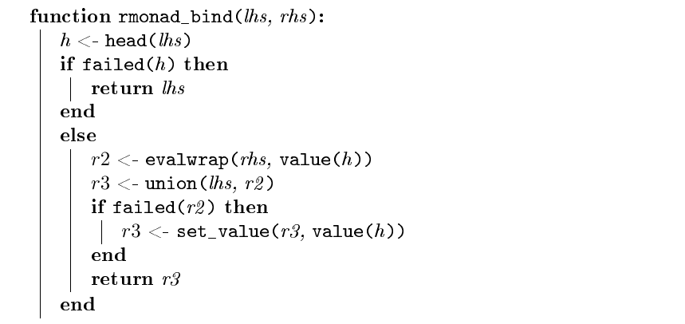

Algorithm 3: The `%>>%` `bind` function. `lhs` and `rhs` are the left hand side and right hand side of the binary `%>>%` operator, respectively. `lhs` is an “Rmonad” object, which is a graph of past operations. `head` extracts the current node in the graph that is being acted on (the “Rmonad” object stores the index of the current head). `failed` returns TRUE if the operation stored in its argument raised an error. `value` returns the data stored in a node (or in the head node of an “Rmonad” object). `evalwrap` evaluates an R function and its arguments and returns a singleton “Rmonad” object (see Algorithm 1). `union` merges two “Rmonad” objects, assigning the head of the new object to the head of the second object. Here the second “Rmonad” object is a singleton, so we are adding one node to the function graph and making it the new head node. `set_value` sets the value of the head node in an “Rmonad” object. `rmonad_bind` returns a new “Rmonad” object with a new value on success and the old value on failure.

The difference between `%>>%` and a true monadic `bind` operator is that the `rhs` of a monadic bind operator is a function ($a \rightarrow M\ b$), whereas the `rhs` of `%>>%` is a normal R function. The `%>>%` operator essentially transforms the `rhs` R function into a function that yields the monadic object. This is carried out within the monadic bind function through the special evaluation offered by `evalwrap`.

While the primary [*rmonad*](https://CRAN.R-project.org/package=rmonad) operator is the monadic pipe operator, `%>>%`, several additional operators are provided for operating on “Rmonad” objects using pipeline syntax (listed in Table 1).

Table 1: A partial list of the supported operators. `lhs` and `rhs` refer to the left-hand and right-hand sides of the given binary operator. `%>>%` is the primary monadic chain operator. `%v>%` is a variant of the monadic chain operator that always caches its input even on a successful run. The `%*>%` operator takes a list of “Rmonad” objects on the left and feeds the values of each as arguments into the function on the right, linking the history of each input “Rmonad” object to the final “Rmonad” object. This operator is important in building branching pipelines. The `%__%` operator is like a semicolon in a programming language, separating independent pipelines but passing on context. The `%||%` and `%|>%`, operators are used in error recovery.

| Operator | Description |
| --- | --- |
| `%>>%` | pass `lhs` as initial argument of `rhs` function |
| `%v>%` | like `%>>%` but caches the `lhs` value |
| `%*>%` | pass list of arguments from `lhs` to `rhs` |
| `%__%` | `rhs` starts a new chain that preserves `lhs` history |
| `%\|\|%` | use `rhs` value if `lhs` is failing |
| `%\|>%` | call `rhs` on `lhs` if `lhs` failed |

The `%>>%` operator by itself can only create linear chains of operations. Mechanisms for lifting this limitation are introduced in the next section.

## 3 Branching and Nesting

In a linear pipeline, the output of each internal function is piped to just one downstream function. In contrast, [*rmonad*](https://CRAN.R-project.org/package=rmonad) allows branching to be formed in one of two main ways: 1) the pipeline’s head may be reset to an internal node and the pipeline can continue growing from there or 2) multiple pipelines may be merged.

The first branching method uses the `tag` function to attach a label to the current head node and the `view` function to change the head node to a previously tagged node. An example of a branched pipeline using these function is shown in Figure 1. A node may be associated with one or more tags.

The second branching method allows multiple pipelines to merged into one. The most direct merge method uses the `%*>%` operator to pass the head value from each “Rmonad” object in the left-hand side list as arguments to the right-hand side function. [*rmonad*](https://CRAN.R-project.org/package=rmonad) also offers a dedicated `loop` function that takes an “Rmonad” object containing a list of values, passes each into monadic function, and connects the histories and final results of each pipeline into a new “Rmonad” node.

The example below demonstrates a loop where nodes where individual elements are dynamically tagged for later access:

```r
m <- loop(
  evalwrap(letters[1:3]),
  function(x){ x %>>% paste0("!") %>% tag(c("letters", x)) }
) %*>% paste0
get_value(m, tag="letters")
```

```
#> $`letters/c`
#> [1] "c!"
#>
#> $`letters/b`
#> [1] "b!"
#>
#> $`letters/a`
#> [1] "a!"
```

```r
get_value(m, tag="letters/b")[[1]]
```

```
#> "b!"
```

The elements of the first argument to the `loop` function (the letters ‘a’, ‘b’, and ‘c’) are passed to `loop`‘s second argument. The second argument is an anonymous function that adds an exclamation mark to the input and tags the resulting value. The tags are hierarchical, thus `get_value(m, tag="letters")` returns all values with the initial tag ’letters’. Specific values can be accessed like files in a path (e.g., "letters/b").

Since [*rmonad*](https://CRAN.R-project.org/package=rmonad) pipelines are branched, there is in general no single output value of the pipeline. Rather, the data contained in the “Rmonad” object is queried using a family of vectorized getter functions. For example, `get_value` will return a list containing the value stored in each node (or `NULL` if no value is stored); `get_error` returns a list of all error messages, `get_warning` returns a list of all warnings, `get_code` returns a list of all code strings, etc. The code below fails on the ‘sqrt’ call and the failing node can be found by searching for code blocks that were not successfully executed.

```r
m <- "a" %>>% paste("cat") %>>% sqrt
get_code(m)[!get_OK(m)]
```

```
#> [[1]]
#> [1] "sqrt"
```

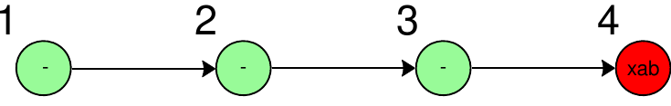

```r
"x" %>>% paste("a") %>>%
         paste("b") %>>%
         log %>% plot(label="value")
```

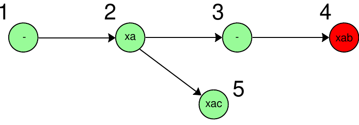

Figure 1: [*rmonad*](https://CRAN.R-project.org/package=rmonad): linear and branched pipelines. The `plot` functions visualize the graph with values in nodes if the values are cached and “-” otherwise. The layout of the plots was modified in the vector editor Inkscape. **Top:** A linear [*rmonad*](https://CRAN.R-project.org/package=rmonad) pipeline that ends in an error. The pipeline begins at node 1 with the value “x”. This is piped into the `paste` function which concatenates the letter “a”. Since the `paste` is successful, the result is stored in node 2 and the value in node 1 is deleted to save memory. The value in node 2 is piped into `paste` again, concatenating the letter “b” and storing it in node 3. The value in node 3 is piped into the `log` function, where an error is raised, terminating this branch, and storing the final failing value, “x a b”, and the error message. The value is only stored at the end node to avoid storing all intermediate values across a pipeline. That way, values are stored when there are errors or where explicitly tagged by the user. **Bottom:** A branched [*rmonad*](https://CRAN.R-project.org/package=rmonad) pipeline and its resulting graph. From node 2, the “Rmonad” object is piped into the `tag` function which annotates the head node (node 2) with the tag “a1” and sets a flag that ensures the value will be cached for later use. After function 4, the “Rmonad” object is piped into `view`, which sets the head of the graph to node 2. Lastly, the value in node 2 is piped into the final `paste` function that concatenates “c”.

```r
"x" %>>% paste("a") %>% tag("a1") %>>%
         paste("b") %>>%
         log %>% view("a1") %>>%
         paste("c") %>% plot(label="value")
```

In addition to branching, [*rmonad*](https://CRAN.R-project.org/package=rmonad) allows complex pipelines to be built from smaller nested pipelines defined in normal R functions (see Figure 2). When data is piped into a function that wraps a nested [*rmonad*](https://CRAN.R-project.org/package=rmonad) pipeline, the input values will be linked to the nodes in the nested pipeline that use the input. In this way, [*rmonad*](https://CRAN.R-project.org/package=rmonad) enables multilevel debugging. Storing the input to each failed function at each nest level allows a programmer to step through the code in the failed node using the input data, without having to rerun the entire pipeline.

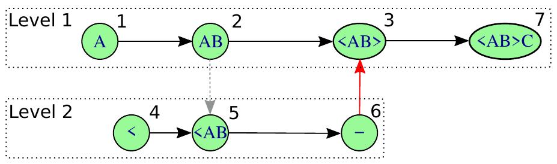

Figure 2: [*rmonad*](https://CRAN.R-project.org/package=rmonad): complex pipelines can be built from smaller nested pipelines. Level 1 is a pipeline where the node 3 represents the computation performed by the pipeline in Level 2. The nodes contains values (“A”, “AB”, etc) if the value is cached by [*rmonad*](https://CRAN.R-project.org/package=rmonad) and contains a “-” if the value is not stored. Arrows show relationships between the nodes. A **black** arrow shows data being passed directly to a new function. A **Gray** arrow points from a node in a parent pipeline to a node in a child pipeline that uses its value. The **red** arrow points from the terminal node in a child pipeline to the node in the parent pipeline that stores its result. Stepping through the pipeline: Node 1 wraps the character “A”, node 2 appends “B”, and node 3 passes “AB” to the function `f`. Next, within the scope of `f`, node 4 starts a new pipeline with the value “<”, node 5 pastes “<” from node 4 to the local *x* variable (which is the value passed from node 2), and finally node 6 appends the closing “>” character. The function `f` returns an “Rmonad” object to node 3. The value of node 6 is transferred to node 3 (thus node 6 is empty, “-”). Finally, node 7 appends “C” and the pipeline finishes successfully.

```r
# Level 2
f <- function(x) {
  "<" %v>% paste(x) %v>% paste(">")
}
# Level 1
"A" %v>% paste("B")
    %v>% f
    %v>% paste("C") %>% plot(label="value")
```

## 4 Evaluation: error handling, metadata, and post-processing

In this section, we expound on how errors are handled in [*rmonad*](https://CRAN.R-project.org/package=rmonad), how nodes are documented and annotated, and how post-processing functionality is added to specify log messages, summarize node output and clean up raised messages.

### 4.1 Exception handling and tracebacks

The core functionality of [*rmonad*](https://CRAN.R-project.org/package=rmonad) is the stateful data piping provided by the monadic operator `%>>%`. Linear chains of operations can be constructed with this operator, where each successful node stores information about the function and results. In the case of an error, [*rmonad*](https://CRAN.R-project.org/package=rmonad) provides access to the traceback and to the inputs to each failing function. Knowing the error messages and the function inputs allows the programmer to step through the failed function and easily diagnose the problem. All information is stored within the “Rmonad” object, rather than in the ephemeral state of an R session.

Here is a concrete example:

```r
m <- "a cat" %>>% log %>>% sqrt
get_error(m)
```

```
#> [[1]]
#> character(0)
#>
#> [[2]]
#> [1] "non-numeric argument to mathematical function"
```

```r
get_code(m)[[2]]
```

```
#> "log"
```

```r
get_value(m)[[2]]
```

```
#> [1] "a cat"
```

Here an illegal value is passed into the natural log function. [*rmonad*](https://CRAN.R-project.org/package=rmonad) catches this error and saves the first failing input and error message. The node index and error message of the failing function can be found with `get_error(m)`, the failing expression can be accessed with `get_code`, and the inputs to the failing function can be retrieved with `get_value`. This approach scales cleanly to large and deeply nested pipelines.

### 4.2 Parsing code strings, docstrings and metadata lists

[*rmonad*](https://CRAN.R-project.org/package=rmonad) leverages R non-standard evaluation to parse the abstract syntax tree of pipeline functions at runtime, prior to evaluation of the functions. [*rmonad*](https://CRAN.R-project.org/package=rmonad) extracts 1) the function’s code as a string, 2) an optional documentation string, and 3) an optional list of metadata. All three items are stored in the “Rmonad” node. For example:

```r
foo <- function(x){
  "This is a docstring"
  list(sysinfo = sessionInfo())
  return(x)
}
```

The first two lines in the function body are the docstring and metadata list, respectively. Each must 1) be of the appropriate type (string and list, respectively), 2) not be assigned to a variable, and 3) not be the final line in the function body. Thus `foo` is a legal R function that can be used naturally outside of the [*rmonad*](https://CRAN.R-project.org/package=rmonad) context. The docstring and metadata would be “dead” lines of code that are evaluated but that are not assigned to any variable or returned. When [*rmonad*](https://CRAN.R-project.org/package=rmonad) parses the function before evaluation, the first two lines will be removed and stored, yielding the following function for evaluation:

```r
function(x){
  return(x)
}
```

The docstring and the function code are stored as simple strings. The metadata list is evaluated within the function environment, giving it access to function input, and then stored.

The metadata is any list associated with a node. It can be used to store static data such as the author’s name, a version for the function, arbitrary notes. It can also store report generation parameters (like code chunks in [*knitr*](https://CRAN.R-project.org/package=knitr)) (Xie 2015). Because the list is evaluated, its contents are dynamic, allowing, for example, session info to be stored or [*knitr*](https://CRAN.R-project.org/package=knitr) parameters to be a function of the input. Whereas [*knitr*](https://CRAN.R-project.org/package=knitr) nests code chunks and their parameters in a text document, [*rmonad*](https://CRAN.R-project.org/package=rmonad) nests text and parameters within the code.

The metadata can be modified freely even *after* the pipeline is run, to enable the user to store notes that are a function of the pipeline results, as well as personal annotations, reminders, or comments on the results.

### 4.3 Post-processing functions: formatting, summarizing, and logging

A built-in use of the metadata is to add formatters, summarizers, and loggers, which are executed automatically after a node is run. For example, a pipeline developer might write the following wrapper around a base 10 log function:

```r
fancy_log10 <- function(x){
  list(
    format_warnings = function(x, xs) {
      sprintf("%s NaNs produced", sum(is.na(x)))
    },
    format_log = function(x, passing) {
      if(passing){
        cat("pass\n")
      } else {
        cat("fail\n")
      }
    },
    summarize = list(len = length)
  )
  log10(x)
}
```

When run, the captured warnings are processed by `format_warnings` and log messages by `format_log`, with the following result:

```r
"a cat" %>>% fancy_log10 -> m
```

```
#> fail
```

```r
c(-2,-1,0,1,2) %>>% fancy_log10 -> m
```

```
#> pass
```

```r
get_warnings(m)
```

```
#> [[1]]
#> character(0)
#>
#> [[2]]
#> [1] "2 NaNs produced"
```

```r
> get_summary(m)[[2]]$len
```

```
#> 5
```

In the first case, an illegal value is passed to the `fancy_log10` function. This leads to a failure in the second node, and the logger prints “fail”. In the second case, the user passes the integers between -2 and 2, storing the result in `m`. Since these are legal values (from R’s perspective), the logger prints the message “pass” after evaluation. When the returned object is printed, the post-processed warning message “2 NaNs produced” is shown. The result of the summarizing function is accessed through the `get_summary` function.

## 5 Case Study: the Iris data

As an example of a simple branching [*rmonad*](https://CRAN.R-project.org/package=rmonad) pipeline with error, warning and run time handling we analyzed the Iris dataset (Anderson 1936; Fisher 1936). The Iris dataset is often used for case studies of statistics and machine learning workflows, and consists of features of three species of flowers: *Iris setosa*, *Iris virginia*, and *Iris versicolor*. Among these features is petal length. We used three statistical methods, (1) ANOVA, (2) Kruskal-Wallis, and (3) t-test, to determine if petal length is significantly different across the three *Iris* species. Some statistical methods are not appropriate for this dataset without data pre-processing. This case study provides an example of running multiple methods using a branching [*rmonad*](https://CRAN.R-project.org/package=rmonad) pipeline, while comparing the output and running times of each method.

Normally, a programmer would run the three methods separately using an R script similar to the following:

```r
# === Load data
data(iris)

# === 3 Statistical Tests (run one at a time)
# (1) Anova
res.aov <- aov(Petal.Length ~ Species, data = iris)
summary(res.aov)

# (2) Kruskal-Wallis
res.kr <- kruskal.test(Petal.Length ~ Species, data = iris)
res.kr

# (3) T-Test
t.test(Petal.Length~Species, data=iris)
```

Using [*rmonad*](https://CRAN.R-project.org/package=rmonad) tags, data can be branched out to encompass the three statistical tests. Here, the R variable $m$ stores the output “Rmonad” S4 object. We must initially tag the branch point node (in this case, the original Iris dataset). Since we gave the first node the tag (“indata”), its value will be cached and can be accessed with the command `get_value(m, tag="indata")`. From here, we can access and pipe (`%>>%`) the viewed “indata” tag into the different statistical tests, as scripted below and visualized in **Figure 3**.

```r
# === rmonad (run together)
m <- {
  "iris dataset"
  evalwrap(iris, tag="indata")
} %>>% {
  "anova"
  res.aov <- aov(Petal.Length ~ Species, data = .)
  summary(res.aov)
}

m <- {
  view(m, "indata")
} %>>% {
  "Kruskal-Wallis"
  res.kr <- kruskal.test(Petal.Length ~ Species, data = iris)
  res.kr
}

m <- {
  view(m, "indata")
} %>>% {
  "t-test"
  t.test(Petal.Length~Species, data=iris)
}
```

The above code could have been chained together using `%>% get_value(tag="indata") %>%` commands, but instead was separately added to the $m$ rmonad object for ease of reading. From the $m$ rmonad objects, we can plot the pipeline. In the following command we label the nodes by node id, documentation, running time, and any errors if they exists.

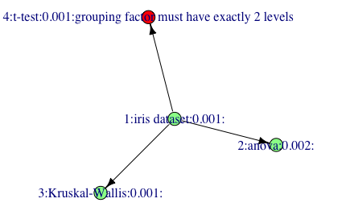

Figure 3: Using [*rmonad*](https://CRAN.R-project.org/package=rmonad) for three statistical tests. The Iris dataset is piped to (1) ANOVA, (2) Kruskul-Wallis, and (3) t-test. Node color reflects whether the test ran (green) or threw an error (red). Time in seconds is shown next to the test name. Errors are annotated on the node. Notice how t-test has the error: "grouping factor must have exactly 2 levels". Of the two tests without errors, ANOVA ran slightly slower than Kruskal-Wallis.

```r
plot(m, label = function(m){paste(get_id(m),
                                  get_doc(m),
                                  get_time(m),
                                  gsub("character\\(0\\)", "", get_error(m)),
                                  sep=":")})
```

In Figure 3, the center node is the iris dataset and has three arrows going outwards toward one red and two green nodes. Of those, the red node near the top represents the t-test and shows the expected error “grouping factor must have exactly 2 levels”. Since we are testing the petal length among the three species, this error is expected. Any errors of the pipeline can also be obtained in a table:

```r
missues(m)
```

```
#>   id  type                                      issue
#> 1  4 error grouping factor must have exactly 2 levels
```

```r
> id=c(2,3)           # place id(s) of end result(s) here
> get_value(m)[id]
```

```
#> [[1]]
#>              Df Sum Sq Mean Sq F value Pr(>F)
#> Species       2  437.1  218.55    1180 <2e-16 ***
#> Residuals   147   27.2    0.19
#> ---
#> Signif. codes:  0 ‘***’ 0.001 ‘**’ 0.01 ‘*’ 0.05 ‘.’ 0.1 ‘ ’ 1
#>
#> [[2]]
#>  Kruskal-Wallis rank sum test
#>
#> data:  Petal.Length by Species
#> Kruskal-Wallis chi-squared = 130.41, df = 2, p-value < 2.2e-16
```

## 6 [*rmonad*](https://CRAN.R-project.org/package=rmonad) in the wild: a comparative genomics case study

An example of a large and complex pipeline that uses [*rmonad*](https://CRAN.R-project.org/package=rmonad) is the orphan gene classification R pipeline, `fagin` (Arendsee et al. 2019) (Figure 4). This pipeline compares genes from one species of interest (the focal species) to genomes of several related species. The first step in the pipeline is to store the user’s session information, which can be used in debugging if needed. Next, the pipeline loops across each species, where, for each species, genomes and annotation data are loaded and validated. Then secondary data (e.g., protein sequences) are derived, and diagnostic summaries are produced and stored. Next, each of the orphan genes in the focal species is compared to each of the related species genomes to create 12 features that are used to classify potential evolutionary relatives of each the focal gene in the target species. Finally, all data for each focal gene is compiled into a description.

The output of this pipeline is a single “Rmonad” object. Further analysis of the pipeline entails a series of queries against this returned object. Warnings and messages are tabulated into an HTML report. Tagged summary data is extracted and used to build diagnostic figures. The primary results are extracted as tabular data and visualized in the final report. Issues with a pipeline can be identified by searching through the raised warnings stored in the “Rmonad” object. Debugging consists of identifying the node of failure, extracting the stored inputs to the failing node, and then stepping through the failing code.

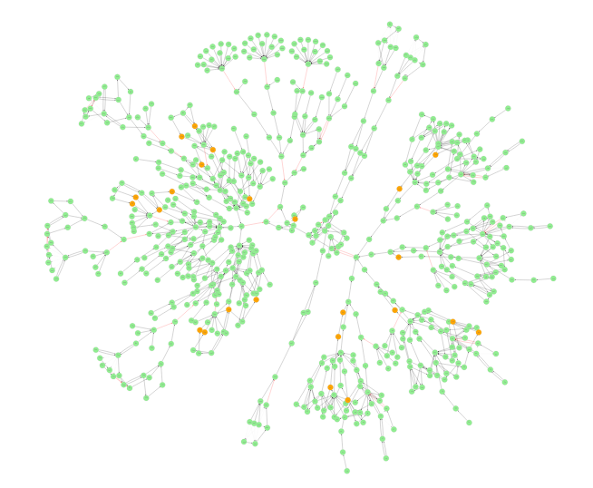

## 7 Conclusion

We implemented a monadic pipeline in R via the [*rmonad*](https://CRAN.R-project.org/package=rmonad) package. [*rmonad*](https://CRAN.R-project.org/package=rmonad) provides an infrastructure for data analysis and report generation. [*rmonad*](https://CRAN.R-project.org/package=rmonad) stores pipeline results and metadata that can be easily explored interactively and collated into reports using tools such as the literate programming package [*knitr*](https://CRAN.R-project.org/package=knitr) (Xie 2015) or the HTML report generator [*Nozzle.R1*](https://CRAN.R-project.org/package=Nozzle.R1) (Gehlenborg et al. 2013).

[*rmonad*](https://CRAN.R-project.org/package=rmonad) integrates a simple profiler into the workflows by automatically capturing the runtime and memory usage of each node. This feature makes it easier for the pipeline developer to identify bottlenecks in the code or potential culprits of memory overflow. Often, a coder must add benchmarking code to key locations in a pipeline. [*rmonad*](https://CRAN.R-project.org/package=rmonad) has *built-in* benchmarking, such that all locations in the pipeline are automatically tested and performance can be checked post-run.

[*rmonad*](https://CRAN.R-project.org/package=rmonad) provides a powerful tool for creating and resolving issue reports. If an [*rmonad*](https://CRAN.R-project.org/package=rmonad) pipeline fails, the resulting object will store all failing functions, their raised error/warning messages and also their inputs. This object can be used to find the error messages, load all inputs to the failing function, and proceed to step through the code until the bug is found. If the user prepends a node that stores the local session data (e.g., `` sessionInfo()`` %__% ... ``), the debugger gains access to the state of the user’s machine (an often-requested item in a bug report). An “Rmonad” object with session info attached contains everything needed to debug the issue. This streamlines issue resolution by improving automation and simplifying submission.

Performance has not been a focus of [*rmonad*](https://CRAN.R-project.org/package=rmonad) up to this point. The package currently lacks support for the re-use of cached values when pipelines are re-run. Also each evaluation step has a high overhead cost relative to lighter pipeline tools like [*magrittr*](https://CRAN.R-project.org/package=magrittr). [*rmonad*](https://CRAN.R-project.org/package=rmonad) pipelines tend to be memory intensive, since they store many intermediate results and metadata in the “Rmonad” objects. Addressing these performance issues is a major goal for future work.

In summary, [*rmonad*](https://CRAN.R-project.org/package=rmonad) integrates the concepts of a pipeline, a build system, a data structure, and an low-level report-generating engine. An [*rmonad*](https://CRAN.R-project.org/package=rmonad) project consists of incremental piped operations (like a pipeline program), supports complex branching projects (like a build system), and produces a data structure that can be computed on to generate dynamic reports.

## 8 Availability

[*rmonad*](https://CRAN.R-project.org/package=rmonad) is published under the GPL-3 license and is available on the Comprehensive R Archive Network (CRAN) and on GitHub at https://github.com/arendsee/rmonad. Systematic documentation of the features with simple examples can be found in the vignettes, available through CRAN.

## 9 Funding

This material is based upon work supported by the National Science Foundation under Grant No. IOS 1546858.

### 9.1 Supplementary materials

Supplementary materials are available in addition to this article. It can be downloaded at RJ-2022-007.zip

### 9.2 CRAN packages used

rmonad, magrittr, pipeR, wrapr, drake, tidycwl, sevenbridges, archivist, trackr, adapr, knitr, Nozzle.R1

### 9.3 CRAN Task Views implied by cited packages

HighPerformanceComputing, ReproducibleResearch

E. Anderson. The species problem in iris. *Annals of the Missouri Botanical Garden*, 23(3): 457–509, 1936.

Z. Arendsee, J. Li, U. Singh, P. Bhandary, A. Seetharam and E. S. Wurtele. Fagin: Synteny-based phylostratigraphy and finer classification of young genes. *BMC bioinformatics*, 20(1): 1–14, 2019.

S. M. Bache and H. Wickham. *Magrittr: A forward-pipe operator for R.* 2014. URL https://CRAN.R-project.org/package=magrittr. R package version 1.5.

G. Becker, S. E. Moore and M. Lawrence. Trackr: A framework for enhancing discoverability and reproducibility of data visualizations and other artifacts in R. *Journal of Computational and Graphical Statistics*, 28(3): 644–658, 2019.

P. Biecek and M. Kosinski. archivist: An R package for managing, recording and restoring data analysis results. *Journal of Statistical Software*, 82(11): 1–28, 2017. DOI 10.18637/jss.v082.i11.

J. Brandt, W. Reisig and U. Leser. Computation semantics of the functional scientific workflow language cuneiform. *Journal of Functional Programming*, 27: 2017.

P. Di Tommaso, M. Chatzou, E. W. Floden, P. P. Barja, E. Palumbo and C. Notredame. Nextflow enables reproducible computational workflows. *Nature biotechnology*, 35(4): 316–319, 2017.

R. A. Fisher. The use of multiple measurements in taxonomic problems. *Annals of eugenics*, 7(2): 179–188, 1936.

N. Gehlenborg, M. S. Noble, G. Getz, L. Chin and P. J. Park. Nozzle: A report generation toolkit for data analysis pipelines. *Bioinformatics*, 29(8): 1089–1091, 2013.

J. Gelfond, M. Goros, B. Hernandez and A. Bokov. A system for an accountable data analysis process in R. *The R journal*, 10 1: 6–21, 2018.

R. Gentleman and D. T. Lang. Statistical analyses and reproducible research. *Journal of Computational and Graphical Statistics*, 16: 1–23, 2007.

S. Koc, N. Xiao and D. Dean. *Tidycwl: Tidy common workflow language tools and workflows.* 2020. URL https://CRAN.R-project.org/package=tidycwl. R package version 1.0.5.

J. Köster and S. Rahmann. Snakemake—a scalable bioinformatics workflow engine. *Bioinformatics*, 28(19): 2520–2522, 2012.

W. M. Landau. *Drake: Data frames in R for make.* 2017. URL https://CRAN.R-project.org/package=drake. R package version 4.4.0.

J. Mount and N. Zumel. Dot-pipe: An S3 extensible pipe for R. *The R Journal*, 2018.

K. Ren. *pipeR: Multi-paradigm pipeline implementation.* 2016. URL https://CRAN.R-project.org/package=pipeR. R package version 0.6.1.3.

C. T. Silva, J. Freire, E. Santos and E. W. Anderson. Provenance-enabled data exploration and visualization with VisTrails. *2010 23RD SIBGRAPI - Conference on Graphics, Patterns and Images Tutorials*, 1–9, 2010.

R. M. Stallman, R. McGrath and P. Smith. *GNU make: A program for directed compilation.* Free software foundation, 2002.

P. Wadler. Comprehending monads. In *Proceedings of the 1990 ACM conference on LISP and functional programming*, pages. 61–78 1990.

N. Xiao and T. Yin. *Sevenbridges: Seven bridges platform API client and common workflow language tool builder in r.* 2020. https://www.sevenbridges.com, https://sbg.github.io/sevenbridges-r/, https://github.com/sbg/sevenbridges-r.

Y. Xie. *Dynamic documents with R and knitr.* 2nd ed Boca Raton, Florida: Chapman; Hall/CRC, 2015. URL https://yihui.name/knitr/. ISBN 978-1498716963.